# Historia del Pensamiento y del Análisis Económico

U1. Pensamiento y análisis económico: historia, métodos y el desarrollo de la economía

Sebastián Freille

Facultad de Ciencias Económicas, UNC

2026-08-14

# **El poder de las ideas y los usos del pasado**

## Las ideas gobiernan el mundo

“Las ideas de los economistas y filósofos políticos, tanto cuando son correctas como erróneas, tienen más poder de lo que comúnmente se entiende. De hecho, el mundo está dominado por ellas. Los hombres prácticos, que se creen exentos de cualquier influencia intelectual, son usualmente esclavos de algún economista difunto.”  
**[J.M. Keynes, *Teoría General*, Cap. 24 (1936)]**

## El economista difunto

- Cada vez que escuchamos hablar de “oferta y demanda”, “mano invisible” o “inflación”, estamos oyendo ecos de debates de hace siglos
- Las políticas económicas de hoy — ajuste, gasto público, impuestos — tienen raíces en discusiones que creíamos enterradas
- **Conocer esas raíces nos permite entender mejor el presente**

## Pero… ¿para qué?

[figure not shown]

But it was so long ago…

## ¿Por qué estudiar HPE?

**Los escépticos preguntan:**

“Why study the wrong opinions of dead men?”  
**[Atribuido a A.C. Pigou]**

**Pero otros responden:**

“It is from the scope and wisdom of the economists of the past that we must reap the knowledge with which to face the future.”  
**[Robert Heilbroner, *The Worldly Philosophers* (1953)]**

“A science which hesitates to forget its founders is lost.”  
**[Alfred Whitehead, *The Aims of Education* (1927)]**

## Razones para estudiar HPE

1. **Entender el origen de las ideas actuales**
   - La “competencia perfecta” de los cursos de micro no es lo que **Adam Smith** tenía en mente
   - El concepto de “neutralidad del dinero” tiene una historia compleja que explica sus límites
2. **Pensar fuera de la caja actual**
   - Si no conocemos otras cajas, ¿cómo sabemos que estamos en la correcta?
   - Muchos conceptos fueron “descubiertos” décadas después de haber sido formulados
3. **Valor pedagógico e integrador**
   - Permite articular diferentes ideas en un sistema coherente [Schumpeter (1954)]
   - Nos enseña *cómo piensan* las grandes mentes

## HPE: tendencias en la profesión

- Ya en 1960 había señales de declive [Gordon (1965)]
  - 86% de instituciones ofrecían cursos de HPE
  - 40% vieron una baja en oferta/requerimientos
  - Profesores jóvenes más reticentes a contratar en el área

| **Período** | **% artículos HPE** |
| --- | --- |
| 1886-1924 | 5.1% |
| 1925-39 | 3.9% |
| 1940-49 | 4.4% |
| 1950-59 | 3.8% |

## HPE en los top journals

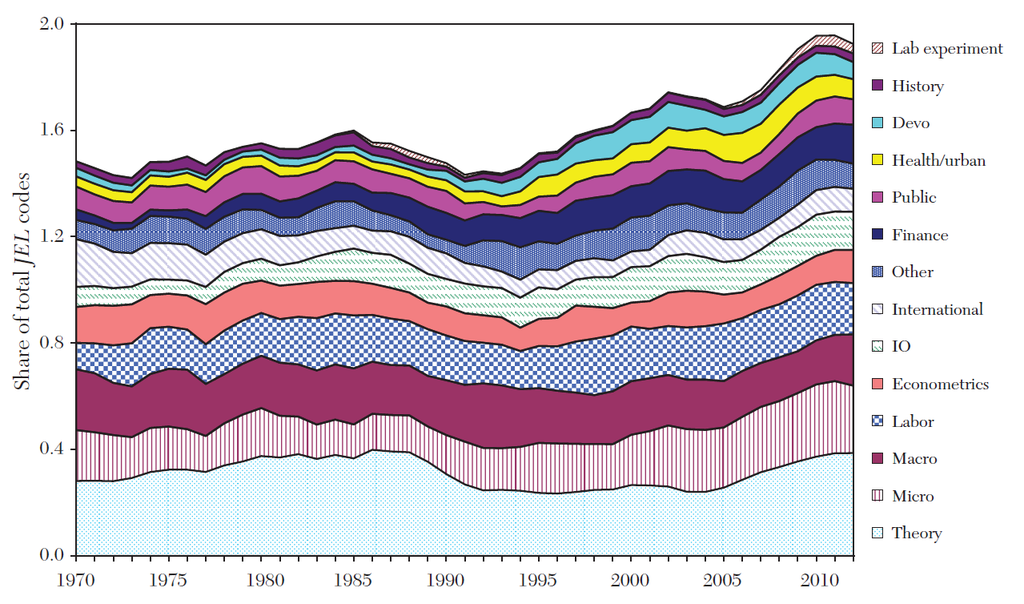

## ¿Está muriendo la HPE?

“Graduate students need at least 4 hours a night of sleep; that is a universal law, so something had to give in the economics curriculum.”  
**[Paul Samuelson (1988)]**

**Sin embargo…**

- Cada vez más investigación, journals y conferencias en HPE
- Resurgimiento en décadas recientes
- Creciente interés en “historia de la macroeconomía”

## La defensa de Blaug

“Ninguna idea o teoría en economía es completamente comprendida excepto como el resultado final de una porción de la historia. **El conocimiento económico es dependiente del camino.** Sin Hayek, Robbins y Pigou, no habría Keynes; sin Keynes, no habría Friedman; sin Friedman, no habría Lucas…”  
**[Mark Blaug (2001)]**

## “Cada escritor crea a sus precursores”

“Su labor modifica nuestra concepción del pasado, como ha de modificar el futuro.”  
**[Borges, “Kafka y sus precursores” (1951)]**

- Vemos el pasado a la luz de las ideas que nos han influido
- **Keynes** “rescató” a **Mandeville**, **Malthus** y otros autores olvidados
- La historia del pensamiento no es lineal ni progresiva

La búsqueda de **precursores** que no influyeron en su tiempo es casi un arte en la disciplina.

## Reconstrucciones racionales e históricas

**Reconstrucción racional**

Traducir ideas del pasado al lenguaje moderno.

- Atractivo: usar herramientas actuales
- Riesgo: hacer que los clásicos parezcan economistas modernos imperfectos

**Reconstrucción histórica**

Entender a los autores en su contexto.

- Ventaja: mayor fidelidad
- Costo: más exigente

“Si tu única herramienta es un martillo, tiendes a tratar cada problema como si fuera un clavo.”  
**[Abraham Maslow]**

# **La economía como ciencia y los modelos filosóficos**

## ¿Es la economía una ciencia?

- La respuesta **depende** de qué consideremos ciencia

**Si ciencia = física matemática:**

- La economía queda afuera
- “Science is measurement”

**Si ciencia = conocimiento con técnicas especializadas:**

- La economía califica

“Ciencia es sentido común refinado. Ciencia es conocimiento instrumentado.”  
**[Joseph Schumpeter]**

## El problema de la historia de la economía

- La economía no es *enteramente* como las ciencias naturales
- Progresa no sólo refinando modelos (vertical) sino expandiendo el rango de modelos (horizontal)
- La realidad social es resultado de elección humana $\longrightarrow$ **inherentemente maleable**

El objeto de estudio de la economía cambia a medida que lo estudiamos.

## Filosofía de la ciencia: contexto

- La filosofía de la ciencia es un campo en el que ha reinado gran agitación desde los 1960s
  - **1920-1950:** Años dorados del positivismo lógico (“las ideas recibidas”)
  - **1960s en adelante:** Grandes críticas y cuestionamientos

**Protagonistas del cambio:**

- Karl Popper
- Michael Polanyi
- Thomas Kuhn
- Imre Lakatos

## Los dos grandes modelos

**Modelo inductivo**

Las investigaciones se inician a partir de la **observación de hechos**, siguen con la formulación de **leyes universales** por inferencia inductiva, y llegan a las “teorías”.

**Flujo:** Observación $\longrightarrow$ Generalización $\longrightarrow$ Teoría

Modelo dominante hasta mediados del siglo XIX

**Modelo hipotético-deductivo**

Incluye al menos una *ley universal* más condicionantes iniciales (el *explanans*), de las cuales se deduce el *explanandum*.

**Flujo:** Hipótesis $\longrightarrow$ Deducción $\longrightarrow$ Contrastación

Formalizado por Hempel-Oppenheim (1948)

## Explicación vs. predicción

**La tesis de la simetría** afirma que explicación y predicción son lógicamente equivalentes.

**Críticos de esta tesis:**

- La predicción no implica explicación y viceversa
- Predicción solo exige *correlación*; explicación requiere algo más
- Se puede predecir bien sin explicar nada (¿*machine learning*?)

**Ejemplo:** La teoría evolutiva de Darwin busca *explicar* el desarrollo de formas biológicas especializadas por selección natural. Pero **no puede predecir** qué forma específica adoptarán.

## El falsacionismo de Popper

**Contribuciones centrales de Karl Popper:**

1. Distinción entre **ciencia y no-ciencia** (criterio de demarcación)
2. Normas para evaluar hipótesis científicas
3. Solución al “problema de la inducción”

**Asimetría clave:** Cualquier afirmación universal puede ser refutada por una sola afirmación particular — pero no es posible derivar afirmaciones universales de afirmaciones particulares.

## El ejemplo del cisne negro

“Ningún número de observaciones de cisnes blancos permite inferir que *todos* los cisnes son blancos, pero un solo **cisne negro** refuta la conclusión.”

**Implicancias:**

- La ciencia se caracteriza por su método de formulación de proposiciones **contrastables**
- No por su contenido ni su pretensión de certeza
- La economía queda entre medio de las ciencias naturales y las humanidades

## Popper en la economía: un ejemplo

**Caso:** La curva de Phillips (1958)

- **Hipótesis:** Existe una relación estable e inversa entre inflación y desempleo
- **Predicción:** Baja inflación $\longrightarrow$ Alto desempleo (y viceversa)
- **Falsación:** La estanflación de los 1970s (alta inflación + alto desempleo) refutó la versión simple
- **Resultado:** Friedman y Phelps propusieron la tasa natural de desempleo

Este es un ejemplo de cómo el falsacionismo funciona en la práctica económica.

## La obsesión por los modelos

**Leijonhufvud (1973)** escribió sobre la “tribu de los economistas” y su obsesión por los modelos:

- El entrenamiento del economista consiste en aprender una secuencia de modelos
- Para los críticos: abstracción excesiva
- Para los defensores: los modelos capturan lo esencial

“Esas observaciones son **relevantes 50 años después** — el entrenamiento del economista consiste esencialmente en aprender una secuencia de modelos.”

## La utilidad de los modelos

“Different contexts require different models. Economists often discard their profession’s most valuable contribution — the **multiplicity of models** — in favor of the search for the one universal model. When models are selected judiciously, they are a source of illumination. When used dogmatically, they lead to hubris and errors in policy.”  
**[Dani Rodrik, *Economics Rules* (2015)]**

## Tres modelos, tres mundos

| Modelo | Resultado | Idealización |
| --- | --- | --- |
| **Oferta y demanda** (Marshall) | Equilibrio eficiente | Mercado competitivo |
| **Dilema del prisionero** (Tucker) | Equilibrio ineficiente | Acciones independientes |
| **Caza del ciervo** (Rousseau) | Equilibrios múltiples | Información imperfecta |

Ninguno está “bien” o “mal” *per se* $\longrightarrow$ cada uno provee un mecanismo válido en diferentes contextos.

## Aplicando los modelos: un ejemplo

**Pregunta de política:** ¿Cómo reducir la contaminación urbana?

- **Modelo 1 (O&D):** Impuesto pigouviano $\longrightarrow$ el mercado ajusta
- **Modelo 2 (Dilema):** Sin regulación, cada empresa contamina $\longrightarrow$ necesitamos enforcement
- **Modelo 3 (Caza):** Depende de expectativas $\longrightarrow$ campañas de coordinación

**La elección del modelo depende del contexto institucional.**

## La economía positiva

**John Neville Keynes** (padre de J.M. Keynes) distinguió en 1891:

**Ciencia positiva**

Conocimiento sistemático sobre “lo que es”

**Ciencia normativa**

Criterios sobre “lo que debería ser”

**Arte**

Sistema de reglas para lograr un fin determinado

La economía positiva es **en principio independiente** de cualquier posición ética o juicios normativos.

## El realismo de los supuestos

**Friedman** argumentó que no tiene sentido testear el “realismo” de los supuestos.

Ejemplos clásicos del argumento “como si” (*as if*):

- **Ley de caída libre** $\longrightarrow$ los cuerpos caen *como si* estuvieran en el vacío
- **Jugadores de billar** $\longrightarrow$ tiran *como si* calcularan ángulos y fuerzas
- **Hojas de árboles** $\longrightarrow$ se distribuyen *como si* buscaran maximizar luz solar

Los supuestos “falsos” pueden generar predicciones correctas. Lo que importa es el **poder predictivo**.

# **Los campos fundamentales del análisis económico**

## Schumpeter: cuatro campos fundamentales

¿Qué distingue a un **economista científico** de todas las otras personas que piensan, hablan y escriben sobre economía?

**Dominio de técnicas y métodos en cuatro campos:**

1. **Historia** — el campo más importante
2. **Estadística** — métodos de medición e inferencia
3. **Teoría** — conceptos, relaciones y métodos
4. **Sociología** — hechos sociales e institucionales

A esto Schumpeter le llamó **análisis económico** [*History of Economic Analysis*, 1954].

## La importancia de la historia

“Los errores más fundamentales de los economistas se deben a déficits de *experiencia histórica* más que a déficits de técnicas y métodos.”  
**[Joseph Schumpeter]**

- El objeto de estudio de la economía es un proceso único en **tiempo histórico**
- El registro no puede ser puramente económico: debe reflejar “hechos institucionales”

## Teoría como caja de herramientas

“*Economic theory is a box of tools.*”  
**[Joan Robinson]**

La teoría tiene **dos roles:**

**Como lenguaje:**

- Conjunto de tautologías
- Sistema de archivo y organización
- Se rige por cánones de lógica formal

**Como cuerpo de hipótesis:**

- Debería juzgarse por poder predictivo
- Solo evidencia fáctica puede mostrar validez
- “Aceptada” o “rechazada” tentativamente

# **Problemas metodológicos centrales**

## Los seis problemas

1. **Economía positiva vs. normativa**
2. **Razones vs. causas**
3. **Naturalismo científico-social**
4. **Abstracción, idealización y *ceteris paribus***
5. **Causalidad en economía y econometría**
6. **Estructura y estrategia: paradigmas y programas de investigación**

## 1. Positivo vs. normativo

- Gran mayoría de economistas creen que existe una línea clara entre hechos y valores

**Pero hay cuestionamientos:**

- Economistas deben *interpretar* especificaciones incompletas del policy-maker
- La ciencia económica concierne **actividad humana** enmarcada en valores
- Gran parte de la economía construida sobre una *teoría normativa de racionalidad*
- Los juicios individuales están influidos por el **propio interés** $\longrightarrow$ posibles sesgos metodológicos

## 2. Razones vs. causas

- Los economistas construyen teorías que ofrecen:
  1. **Explicaciones causales** de por qué los individuos eligen como eligen
  2. Relatos sobre las **razones** detrás de sus elecciones

**Davidson (1963):** “Lo que distingue las razones que explican una acción de las razones que fallan en explicarla es que las primeras son también **causas** de la acción.”

**Problema adicional:** Las creencias y preferencias suelen depender de *errores e ignorancia*.

## 3. Naturalismo científico-social

- La economía es la ciencia social que más se asemeja a las ciencias naturales

**Tres cuestiones centrales:**

1. ¿Hay diferencias fundamentales en la estructura de teorías y explicaciones?
2. ¿Hay diferencias en los objetivos? Las ciencias naturales buscan explicar y predecir; la economía además busca “entender”
3. ¿Son los fenómenos sociales demasiado irregulares para ser capturados en un marco de leyes?

## 3. Naturalismo (cont.)

**Weber (1904)** enfatizó la importancia de “entender” (*Verstehen*) en las ciencias sociales.

- Esto introduce un fuerte elemento de **subjetividad**
- La economía estudia fenómenos donde las **elecciones humanas** son centrales
- ¿Son esas elecciones suficientemente regulares como para formular leyes?

## 4. Abstracción y *ceteris paribus*

- La economía suele ser criticada por la fuerte dependencia de la **abstracción e idealización**
- Supuestos típicos: racionalidad perfecta, información completa
- Sin una buena dosis de abstracción, resulta difícil trabajar con todas las complicaciones del mundo real

Los enunciados de la economía son verdaderos estrictamente bajo la cláusula *ceteris paribus* (“todo lo demás constante”).

**¿Cuánta abstracción es legítima?** ¿Cuán validados están estos supuestos por la evidencia empírica?

## 5. Causalidad en economía

[figure not shown]

Foto de gaviota posada en una barra doblada

## 5. Causalidad: ¿por qué importa?

- Muchos enunciados económicos se asemejan a enunciados causales: “cuando sube $P$, baja $Q_d$”
- Pero la **causalidad** no fue explorada explícitamente hasta recientemente

**Razones por las que importa:**

1. Conocer y atacar las **verdaderas causas** de un problema
2. **Diseñar** políticas e intervenciones correctas
3. **Distinguir** correlación de causación

## 5. Causalidad: la experimentación

**Revolución de la causalidad:** Reencarnación moderna del debate $\longrightarrow$ *randomized controlled trials* (RCTs).

- Aleatorización de individuos en grupos de **tratamiento** y **control**
- La variación en resultados se debe *totalmente* al factor de interés

**Problemas:**

- Representatividad: ¿aplican resultados de Uganda a México?
- Ética: ¿es aceptable negar tratamiento a un grupo de control?

## 6. Paradigmas y programas de investigación

- ¿Existe alguna **estructura teórica** que guíe y unifique la investigación en economía?
- **Kuhn**: la ciencia avanza por “revoluciones” que cambian el paradigma dominante
- **Lakatos**: los programas de investigación tienen un “núcleo duro” protegido por hipótesis auxiliares

La comparación de la estructura económica con estos marcos ha echado luz sobre las ventajas y deficiencias de la teoría económica — por ejemplo, el supuesto de que el equilibrio *existe* y *se logra* rara vez se cuestiona.

# **Preguntas para reflexionar**

## Tres preguntas para pensar

1. Si los economistas usan las mismas matemáticas que los físicos, **¿por qué hay tanto desacuerdo en economía?**
2. **¿Es posible hacer economía “libre de valores”?**
3. **¿Qué ideas económicas actuales podrían estar tan equivocadas como el mercantilismo?**

# **Bibliografía**

## Lecturas principales

- **Blaug, M. (2001).** No history of ideas, please, we’re economists. *Journal of Economic Perspectives*, 15(1), 145-164.
- **Schumpeter, J. A. (1954).** *History of Economic Analysis*. Part I, Ch. 1-2 [pp. 1-22].
- **Friedman, M. (1953).** The methodology of positive economics. En *Essays in Positive Economics*.
- **Gordon, D. F. (1965).** The role of the history of economic thought in the understanding of modern economic theory. *AER*, 55(1/2), 119-127.
- **Hausman, D. M. (2024).** Philosophy of Economics. *Stanford Encyclopedia of Philosophy*.

## Lecturas complementarias

- **Leijonhufvud, A. (2006).** The uses of the past. University of Trento Discussion Paper No. 3.
- **Rodrik, D. (2015).** *Economics Rules*. Ch. 1 [pp. 13-30].
- **Blaug, M. (1985).** *La metodología de la economía*. Cap. 1 [pp. 19-32].
- **Card, D., & DellaVigna, S. (2013).** Nine facts about top journals in economics. *Journal of Economic Literature*, 51(1), 144-161.